# Approximate String Matching with `stringdist`

Riki Saito

November 2, 2016

## Introduction

Data cleaning is an unavoidable (and might I say exhausting) process in any analysis with real data. In this post we will explore an elegant solution to a particular data cleaning task: identifying redundant records in a data set.

The R package we will be using in this post is calld [`stringdist`](https://github.com/markvanderloo/stringdist), an awesome package written by Mark van der Loo.

## Record Linkage

A common task in a data cleaning procedure is the identification of duplicate records. This is an easy task if you have duplicate records that match exactly, in which case all you would need to do is obtain distinct records (e.g. in SQL, `select DISTINCT` would solve this issue). However in some cases, you may have records that belong to the same entity but do not necessary match exactly. This happens very frequently with names of people. For example:

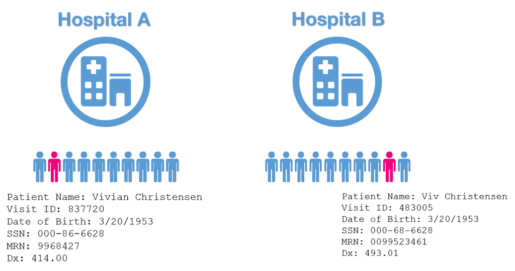

(source: http://healthcarehotspotting.com/wp/wp-content/uploads/LinkageDefinition1.png)

Anyone can look at this and tell that **Vivian Christensen** and **Viv Christensen** are the same person. This task of identifying similar records is commonly known as **Record Linkage**.

Record linkage is defined as the task of identifying records in a data set (or across multiple data sets) that belong to the same entity. An entity could refer to people, products, institutions, etc.

And sure, one could simply fix this by hand by inspecting the whole data and identifiying duplicates by “brute force”. However, this is not scalable for a large data set as it becomes too costly (in terms of resources such as time and labor). A popular solution to this problem is the use of a technique called **Approximate String Matching**.

## Approximate String Matching

Approximate String Matching is a pattern matching algorithm that computes the degree of similarity between two strings (rather than an exact match). In a nutshell, approximate string matching algorithms will find some sort of matches (single-character matches, pairs or tuples of matching consecutive characters, etc), and produce a quantitative measure (distance/dissimilarity) of how alike two strings are.

While there are numerous different of existing approximate string matching algorithms, there is a large school of methods that rely on what is known as edit distance. Edit distance is simply the number of “edits” (or operations) required to transform from one string to another. There are four different operations: insertion, deletion, substitution, and transposition (however not all algorithms considers this operation).

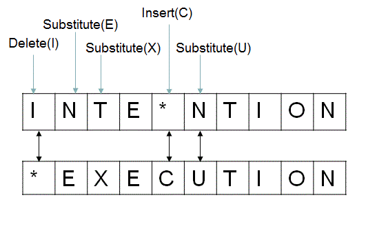

(source: http://www.ideserve.co.in/learn/img/editDistance_0.gif)

For example, between the words **INTENTION** and **EXECUTION**, a total of 5 operations are required to transform from one word to the other. Therefore we have an edit distance of 5.

Now let’s see how approximate string matching algorithms are used in practice.

## Evaluating Different Algorithms

We will use product names listed on Amazon as an example. We have 8 different product and their names as listed on the website:

| Amazon Product Listings | Group (Product Line) |
| --- | --- |
| Bose SoundLink Mini Bluetooth Speaker II (Pearl) | 1 |
| Bose SoundLink Mini Bluetooth Speaker II (Carbon) | 1 |
| Bose SoundLink Color Bluetooth speaker II - Soft black | 2 |
| Bose SoundLink Color Bluetooth Speaker II - Polar White | 2 |
| UE BOOM 2 Phantom Wireless Mobile Bluetooth Speaker (Waterproof and Shockproof) | 3 |
| UE BOOM 2 Yeti Wireless Mobile Bluetooth Speaker (Waterproof and Shockproof) | 3 |
| UE ROLL 2 Volcano Wireless Portable Bluetooth Speaker (Waterproof) | 4 |
| UE ROLL 2 Atmosphere Wireless Portable Bluetooth Speaker (Waterproof) | 4 |

In this post, we are going to extend the definition of record linkage: say we have a list of product names (Stock Keeping Units). The goal is to identify product listings that belong to the same Product Line (PL), or model (e.g. Bose Soundlink Mini II, Bose Soundlink Color II). So we should expect to see a smaller distance for product listings within in the same Group (Product Line), and a large measure of distance for listings belonging to different groups.

The algorithms we will consider are the following:

| Algorithm | Description |
| --- | --- |
| Longest Common String | Length of longest substring present in both strings |
| Optimal String Alignment (Damerau-Levenshtein Distance) | Number of edit operations needed to transform from one string into the other |
| Cosine Distance | Similarity (from 0 to 1) between two strings, measured using the angle calculated between two vectorized strings |

```r
# load packages
pacman::p_load(stringdist, dplyr, tm, gplots)

# function to remove all white space
trim <- function(x) gsub("^\\s+|\\s+$", "", x)

# function to clean strings (lower case, remove punctation, remove all white
# space)
str_clean <- function(strings) {
    require(dplyr)
    require(tm)
    strings %>% tolower() %>% removePunctuation() %>% stripWhitespace() %>%
        trim()
}

# product listings from amazon
prods = c("Bose SoundLink Mini Bluetooth Speaker II (Pearl)", "Bose SoundLink Mini Bluetooth Speaker II (Carbon)",
    "Bose SoundLink Color Bluetooth speaker II - Soft black", "Bose SoundLink Color Bluetooth Speaker II - Polar White",
    "UE BOOM 2 Phantom Wireless Mobile Bluetooth Speaker (Waterproof and Shockproof)",
    "UE BOOM 2 Yeti Wireless Mobile Bluetooth Speaker (Waterproof and Shockproof)",
    "UE ROLL 2 Volcano Wireless Portable Bluetooth Speaker (Waterproof)", "UE ROLL 2 Atmosphere Wireless Portable Bluetooth Speaker (Waterproof)")

# cleaned product listings
clean_prods = str_clean(prods)

n = length(clean_prods)

# distance methods
methods <- c("lcs", "osa", "cosine")
q <- c(0, 0, 3)  #size of q-gram

dist.methods <- list()

# create distance matrix for every pair of listing, for each method
for (m in 1:length(methods)) {
    dist = matrix(NA, ncol = n, nrow = n)  #initialize empty matrix
    # row.names(dist) = prods
    for (i in 1:n) {
        for (j in 1:n) {
            dist[i, j] <- stringdist(clean_prods[i], clean_prods[j], method = methods[m],
                q = q[m])
        }
    }
    dist.methods[[m]] <- dist
}
```

Let’s visualize the results using heat maps. Note that in these figures, a darker red color corresponds to a closer distance between the pair of product listing names.

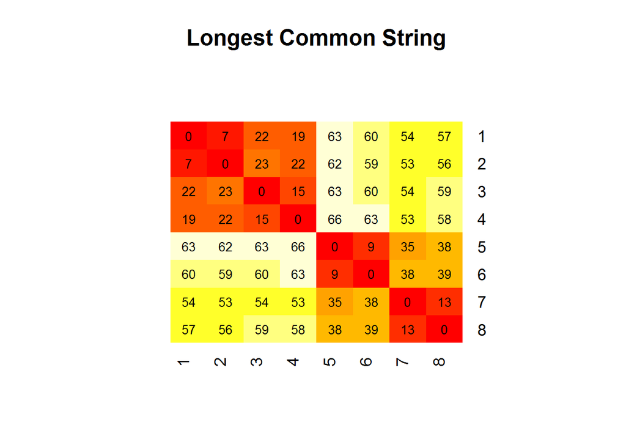

```r
# visualize results using heat
heatmap.2(x = dist.methods[[1]], Rowv = FALSE, Colv = FALSE, dendrogram = "none",
    cellnote = dist.methods[[1]], notecol = "black", notecex = 1, trace = "none",
    key = FALSE, margins = c(7, 11), main = "Longest Common String")
```

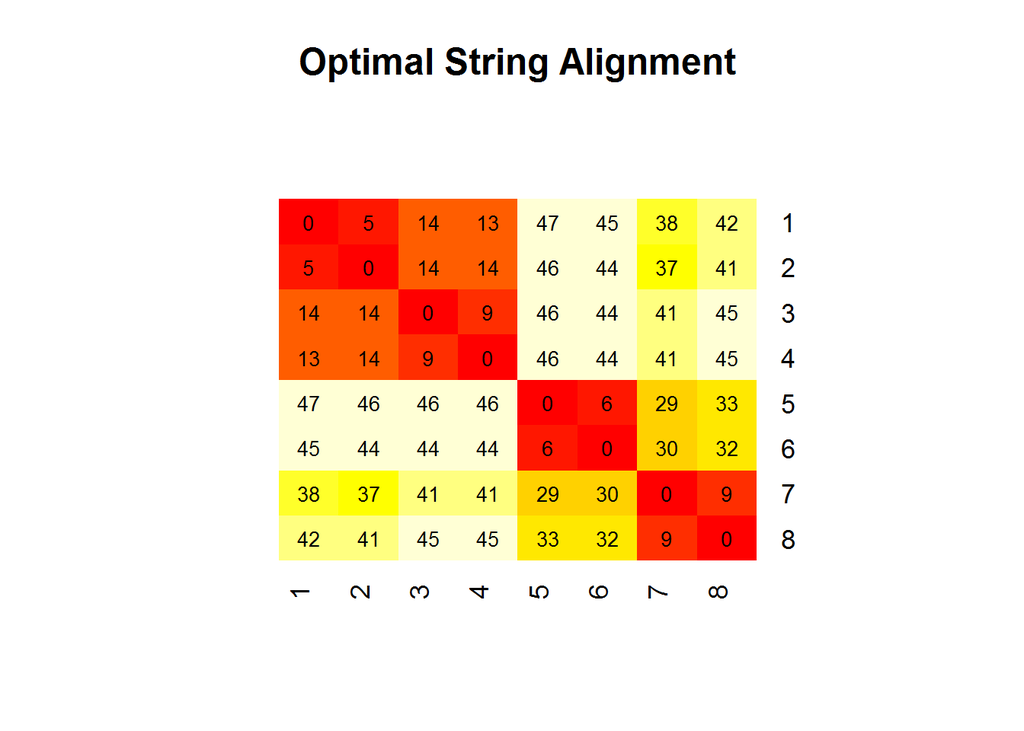

```r
heatmap.2(x = dist.methods[[2]], Rowv = FALSE, Colv = FALSE, dendrogram = "none",
    cellnote = dist.methods[[2]], notecol = "black", notecex = 1, trace = "none",
    key = FALSE, margins = c(7, 11), main = "Optimal String Alignment")
```

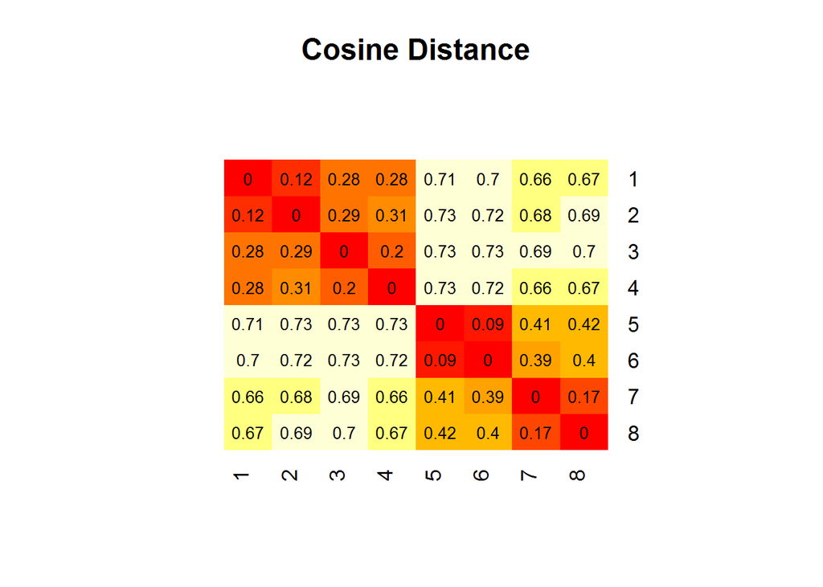

```r
heatmap.2(x = dist.methods[[3]], Rowv = FALSE, Colv = FALSE, dendrogram = "none",
    cellnote = round(dist.methods[[3]], 2), notecol = "black", notecex = 1,
    trace = "none", key = FALSE, margins = c(7, 11), main = "Cosine Distance")
```

We can see all three methods produce similar results, and as we suspected, all product listings within the same group [(1,2, (3,4), (5,6), (7,8)] have a small relative measure of distance compared to listings outside of its group. With an appropriate threshold or cutoff, we are then able to categorize these listings into the appropriate groups:

```r
#hierarchical clustering with cut-off of 0.2
clusters <- hclust(as.dist(dist.methods[[3]]))
cbind("Product Listing" = prods, "Cluster" = cutree(clusters, h = .2))
```

```
##      Product Listing
## [1,] "Bose SoundLink Mini Bluetooth Speaker II (Pearl)"
## [2,] "Bose SoundLink Mini Bluetooth Speaker II (Carbon)"
## [3,] "Bose SoundLink Color Bluetooth speaker II - Soft black"
## [4,] "Bose SoundLink Color Bluetooth Speaker II - Polar White"
## [5,] "UE BOOM 2 Phantom Wireless Mobile Bluetooth Speaker (Waterproof and Shockproof)"
## [6,] "UE BOOM 2 Yeti Wireless Mobile Bluetooth Speaker (Waterproof and Shockproof)"
## [7,] "UE ROLL 2 Volcano Wireless Portable Bluetooth Speaker (Waterproof)"
## [8,] "UE ROLL 2 Atmosphere Wireless Portable Bluetooth Speaker (Waterproof)"
##      Cluster
## [1,] "1"
## [2,] "1"
## [3,] "2"
## [4,] "2"
## [5,] "3"
## [6,] "3"
## [7,] "4"
## [8,] "4"
```